# Rummikub and Branch & Bound

How a machine decides whether your hand can open

> **Draft.** This document is a first pass at explaining, to a human reader, the exact algorithm used by `solve_opening()` in this repository. It is written “from the doubts”: every section starts from a real question that was asked while reading the code, and each question is the door to a formal concept. Sections will be deepened one by one.

# A question from the game table

You draw your 14 tiles in Rummikub. To “open”, you must lay on the table one or more melds whose total is **at least 30 points** — and you may touch no tile that is already on the board.

Natural questions:

1. **How often** can a random hand of 14 tiles open on its first turn?
2. If it cannot, **how many draws** do you need on average before it can?

The answer to (1) is **about 49.5%** of hands, and (2) is **about 2.4 draws** (we will come back to these numbers in Honest science).

But notice what the machine must do to answer (1): for *each* simulated hand it must decide exactly whether a 30-point opening exists. “Exactly” is the hard part. A hand of 14 tiles can form hundreds of candidate melds, and melds share tiles, so “try all combinations” is not obviously fast.

**Note**

**Concept box — optimization** Deciding *does an opening exist?* is an optimization problem: find the maximum total score achievable with a valid set of melds, and compare it to 30. The algorithm that solves it exactly — in milliseconds — is the topic of this text: **branch & bound**. (It is not the *only* way to solve it exactly, and we will meet a much shorter polynomial-time method in the next section. Its exact answer is not what this text is for; its *reasoning* is.)

# The mathematical problem under the hood

What does it mean that the melds are *disjoint*? Simply that you cannot play the same physical tile twice: if a meld uses the tile `4blue`, no other meld in your opening may use it. Melds that share no tile are called **disjoint**.

This little word is the heart of the problem. Think of each meld as a *set* of tiles. We must choose a collection of sets that:

- do not **overlap** (the disjoint condition), and
- **maximize** the sum of their values.

This is a well-known combinatorial problem:

**Important**

**Formal concept — weighted set packing** Choosing non-overlapping sets to maximize the total value is **weighted set packing** — a problem with deep roots in combinatorial optimization. It is equivalent to an **integer program (0-1)**: one binary variable per candidate meld, a constraint *sum ≤ 1* for every tile (each tile can belong to at most one chosen meld), and an objective of maximizing the weighted sum (Barnhart et al. 1998). Set packing is one of the original NP-complete problems identified by Karp in 1972 (Karp 1972), and its many relatives are catalogued in the standard reference on intractability (Garey and Johnson 1979). Even *approximating* it is hard in general: it cannot be approximated within a factor of Ω(k/log k) unless P = NP (Hazan, Safra, and Schwartz 2006), where k is the largest size of a set.

Read that carefully and you will notice it is a statement about **set packing in general** — sets of any size, any weight, any universe. It is an *upper bound* on the difficulty of our problem, not a verdict about it. And Rummikub turns out to be a remarkably narrow slice of that universe, with a much friendlier answer.

**Note**

**But Rummikub itself is easy — it is in P** van Rijn, Takes and Vis give an algorithm that solves the *Rummikub puzzle* — “given a hand, form disjoint valid runs and groups whose total score is maximized” — in polynomial time (Rijn, Takes, and Vis 2016). The device is a **notebook far too small to forget**: sweep the tile values 1, 2, …, n in order, and for each colour keep a single counter saying *how long is the same-colour run currently in progress, capped at 3*.

Why is the cap legitimate? Because the moment a run reaches length 3 it is already a legal meld, and every further tile of it simply **adds its own value**: 3+4+5 scores 12, and extending that meld with the 6 and the 7 adds 13 more. Lengths 4, 5, 6… never require a separate decision — only “0, 1, 2 or ≥ 3” does. So the whole past of the computation collapses into that tiny state, and the algorithm moves forward once, **never backtracking**.

For one colour with `m = 2` copies there are only `C(m+3, 3) = 10` distinct run configurations, which bounds the entire state space at `n × k × f(m)` — a few hundred entries for the real game (Rijn, Takes, and Vis 2016). Since `k = 4` colours and `m = 2` copies are *fixed* in standard Rummikub, the only parameter that grows is `n`, and the algorithm is therefore **linear in the number of tile values**. The two jokers cost one extra dimension with three states (0, 1 or 2 jokers used), i.e. a constant factor.

Why does this matter to you as a player? Because it settles what the right question is. Had the Rummikub puzzle genuinely been NP-hard, every strategic question built on top of it would be expensive, and the honest engineering answer would be to approximate. It is not. The inner question — *how good is this hand?* — can be answered **exactly, cheaply and deterministically**. What is expensive is asking it *very many times*, which is exactly what the strategy questions of objective 6 do.

So why is this repository built on branch & bound rather than on the dynamic program of (Rijn, Takes, and Vis 2016)? Because of the purpose of this text. **The dynamic program is shorter and faster, but it is not transparent: it produces the right number without ever showing the structure behind it.** The decision tree *is* the structure of the answer. Each node is a question a player might genuinely ask at the table — *do I play this tile here, or here, or not at all?* — and the bound that prunes a subtree is a sentence of plain meaning. That transparency is the entire reason this document exists.

# The idea: search, but search smartly

What is branch & bound, and what are the branches?

Branch & bound answers two questions at once:

- **How do we explore all possibilities without repeating any?** (*branching*)
- **How do we skip most of them anyway?** (*bounding* + *pruning*)

Branching builds a **decision tree**. At every node we pick one tile and ask: *do we discard it, or use it in one of the melds that contains it?* Each answer is a branch. Every complete path through the tree is a complete decision about every tile, and the tree visits every possible play exactly once. The general scheme — *branch*, *bound*, *prune* — is one of the oldest tools of combinatorial optimization; its first systematic treatment dates back to Lawler and Wood’s survey (Lawler and Wood 1966).

We will use one hand throughout the text. Call it **h1**:

- `2blue 3blue 4blue 5blue` plus an extra `4blue`, plus `4black 4yellow`.

It can form four melds:

| Meld | Tiles | Points |
| --- | --- | --- |
| M01 | 2 3 4 (blue) | 9 |
| M02 | 2 3 4 5 (blue) | 14 |
| M03 | 3 4 5 (blue) | 12 |
| M04 | 4blue 4yellow 4black | 12 |

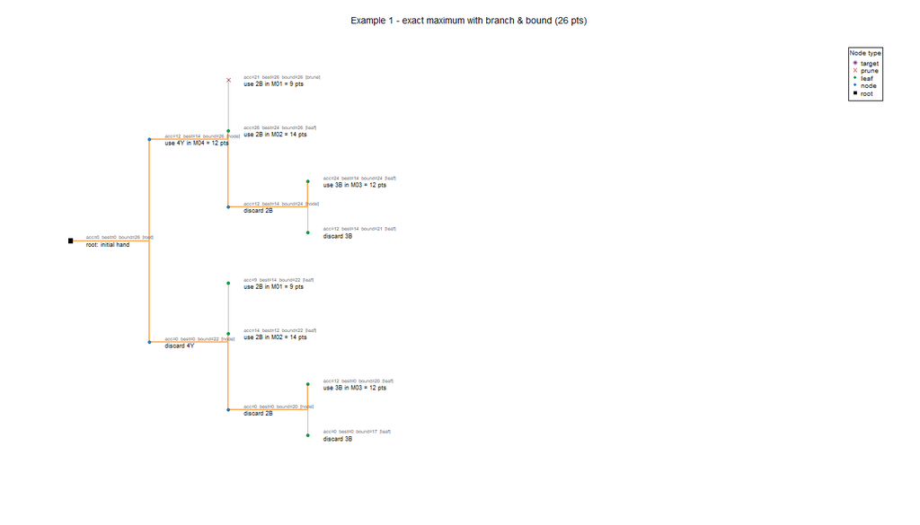

Search tree for h1 with no target (exact maximum). Orange edges highlight the path of each node that improved the best score; the red `x` is a pruned branch.

## The most constrained tile

What is the most constrained tile, and why is it safe to force the choice on it?

At the root, h1 has six tile types. The algorithm does not pick a random tile: it picks the one that belongs to the *fewest* usable melds. That is `4yellow`, which appears only in M04. The question “discard it or use it?” then splits the problem in two, and **every** possible play falls into one of the two branches — nothing is lost, so the search stays exact.

**Note**

**Formal concept — MRV / fail-first** Picking the most restricted variable first is the **minimum remaining values (MRV)** heuristic of constraint satisfaction (CSP), also known as the **fail-first principle**: a tile that fits in few melds is the one most likely to close a branch quickly, and failing early costs the least.

The “safe” property is what mathematicians call **completeness**: we only ever reduce a node to the two cases *use* or *discard*, and those two cases cover everything.

# The bound: an impossible budget

What exactly does `acc + sum(remaining * values)` do?

Two ingredients:

- `acc` — the score already accumulated along the path from the root to this node;
- `remaining` — how many copies of each tile type are still unused;
- `values` — the point value of each tile type.

The quantity `acc + sum(remaining * values)` is a **bound**: the best score this node could *possibly* reach. Why “possibly”? Because it assumes we can use **every** remaining tile in a meld, simultaneously — which is usually impossible, since melds must be disjoint. It is an *optimistic* estimate.

In the h1 trace, the root reports:

```
[N01] remaining: 2bluex1 3bluex1 4bluex2 4yellowx1 4blackx1 5bluex1
      acc= 0  best= 0  BOUND=acc+sum(remaining)=26
```

**Important**

**Formal concept — relaxation and admissible heuristics** Dropping the “disjoint” restriction gives an easier problem whose answer is an upper bound on the real one. That is exactly the idea behind the **linear programming relaxation** that powers modern solvers and **branch-and-price** methods for huge integer programs (Barnhart et al. 1998). A heuristic that never underestimates is called **admissible**, and it is exactly the condition that makes the search optimal (the same condition A* requires for shortest paths).

Because every tile value is non-negative, the bound can only **decrease** as we go down the tree. We will use that in the next section.

# Pruning: cutting without breaking

What is pruning? And why does it not make the algorithm any less exact?

At any node we know two numbers: the current global best score `best`, and the node’s own optimistic bound. If

```
bound <= best
```

then this node cannot possibly beat the best we already found — even if it used every remaining tile. We **discard the whole subtree**. In the h1 trace this happens exactly once, at the very end:

```
[N13] remaining: 5bluex1                   acc=21  best=26  BOUND=acc+sum(remaining)=26
      PRUNE: bound 26 <= best 26 -> this branch cannot improve, discard
```

**Why is it exact?** Because the bound never underestimates: any score reachable inside the subtree is *at most* the bound, so if the bound cannot beat `best`, neither can any descendant. Cutting such a subtree loses no possible improvement. This is a **dominance argument**, and it is the same logic behind **alpha-beta pruning** in game tree search (there the roles of `best` are played by alpha/beta).

# How the tree is explored: recursion and backtracking

Why does the ‘use 3blue’ branch not appear until much later? Where did it go?

Look again at the trace. `3blue` can be used in M03 (`3blue 4blue 5blue`). You would expect that branch right after the root’s “discard `4yellow`” branch. But in the trace it appears **after** a leaf, like this:

```
[N01] ... BOUND=26
  MOST CONSTRAINED tile: 4yellow
  BRANCH A: discard 4yellow
  [N02] ...
    BRANCH A: discard 2blue
    [N03] ...
      MOST CONSTRAINED tile: 3blue
      BRANCH A: discard 3blue
      [N04] remaining: 4bluex2 4blackx1 5bluex1  acc= 0 ... best=0
        leaf: no meld fits anymore -> best=0
      BRANCH B: use 3blue in meld [12=3blue 4blue 5blue]
      [N05] remaining: 4bluex1 4blackx1        acc=12 ... best=0
        leaf: no meld fits anymore -> best=12
```

The “missing” branch is **N05** — it simply comes *after* the leaf N04, not before it. The algorithm is **depth-first**: it goes down a branch as far as it can (to a leaf), then *backtracks* to the last unfinished decision and tries the other side. The exploration is a stack: enter a node, descend, return, descend the next option.

**Note**

**Formal concept — DFS and backtracking** This is **depth-first search** over a recursion tree, the classic **backtracking** pattern: *choose → expand → undo*. The call stack of the program *is* the memory of the pending decisions. Everything you see in the console trace `[N01] ... [N13]` is the stack being pushed and popped.

The “bitácora” quality of the trace — the indentation shows the depth, the `[N..]` number shows the visit order — is precisely what makes the algorithm teachable: *read the trace in order and you are watching the stack breathe*.

# The shortcuts: when there is nothing to search

Two special cases are solved with **zero** search:

**Shortcut 1 — you already win.** If any single meld already reaches the target (≥ 30), you can open with just that meld. Example: the hand `6..13 blue` has a run of eight tiles worth 76 points, so the machine answers immediately. The trace prints `done in zero time`.

**Shortcut 2 — you can never win.** If the sum of *all* tile values in the hand is below the target, even using every tile is not enough. h1 (sum 26) hits this case with target 30.

These are the **trivial cases** of the problem — they do not change the worst-case complexity, but they make the *typical* game instant.

# Best-first is not greedy

Here is the subtlest question of all: if the branches are ordered by points, is the algorithm not just “take the best and done” — a greedy method?

No, and the difference is crucial:

- **Ordering** decides *which* branch to explore first. Branch & bound orders the “use” branches by meld value, best first. But it still explores *every* non-pruned branch. The ordering is just a preference; it changes *speed*, never *correctness*.
- **A greedy method** *decides* permanently: take the best meld, remove its tiles, repeat — and never reconsider. It can walk straight into a trap.

Example 3 in the demo shows the trap. The hand is:

```
2blue 3blue 4blue 5blue 6blue  3yellow 3black 4yellow 4black
```

The greedy method (always take the most valuable meld) returns **20 points**. The exact optimum is **24** — a combination the greedy never considers because its first, locally best choice blocks it.

| Method | Score |
| --- | --- |
| Greedy (best first) | 20 |
| Branch & bound | 24 |
| Brute force | 24 |

**Warning**

**Lesson.** A *heuristic ordering* inside an exhaustive search is not the same as a *heuristic decision*. The first only reorders the work; the second may throw away the optimum. This confusion between “order of exploration” and “choice” is the most common source of the greedy illusion.

# Honest science: verify, don’t trust

How do we *know* the exact search is actually exact? By testing it against an independent, dumber oracle, and by acknowledging the bugs we find.

**Brute force as oracle.** The demo implements `brute_max()`: it enumerates every combination of disjoint melds with no pruning and no heuristics — correct by construction, too slow for large hands. Comparing the two over random hands:

```
Verified 200 random hands in 1.5s
  branch&bound == brute force in 200/200 cases
  The greedy fell short in 2 of 200 hands (1.0%)
```

**Monte Carlo as statistics.** The opening analysis simulates thousands of random hands (exactly solved), giving the numbers from the opening of this text: 49.5% of hands open (95% CI 48.1%–50.8%), 2.40 draws on average.

**And the bug we actually found.** While teaching the algorithm, a regression test revealed that `possible_melds()` could generate *runs of two tiles* (12-13 of one colour = 25 points), which are not legal melds. That inflated the opening statistics (the old 53.5% is wrong). The fix was one guard in the loop; a regression test now locks it. Two lessons:

- an *algorithmically* correct search is worthless if the *case base* (what counts as a meld) is wrong;
- statistics published from a buggy generator are quietly wrong — which is why the tests live next to the simulations.

**Note**

**Methodological box.** Exact code is not enough; you need (a) an independent oracle for small instances, (b) statistical sanity checks on large ones, and (c) regression tests on every bug found. All three are in this repository.

# Reproduce it

Everything in this text is reproducible from the repository root:

```bash
# The traced algorithm, the greedy trap, the brute-force oracle, the tree
Rscript scripts/demo_branch_and_bound.R

# The opening statistics (Monte Carlo with exact solving)
Rscript scripts/06_opening_analysis.R

# The test suite (including the regression test for the 2-tile run bug)
Rscript -e "testthat::test_file('tests/test_objective_06.R')"
```

The figures in this document are generated by the demo script and written to `results/` (a directory of generated outputs, not tracked in git).

## References

Barnhart, Cynthia, Ellis L. Johnson, George L. Nemhauser, Martin W. P. Savelsbergh, and Pamela H. Vance. 1998. “Branch-and-Price: Column Generation for Solving Huge Integer Programs.” *Operations Research* 46 (3): 316–29. https://doi.org/10.1287/opre.46.3.316.

Chandra, Barun, and Magnús M. Halldórsson. 2001. “Greedy Local Improvement and Weighted Set Packing Approximation.” *Journal of Algorithms* 39 (2): 223–40. https://doi.org/10.1006/jagm.2000.1155.

Garey, Michael R., and David S. Johnson. 1979. *Computers and Intractability: A Guide to the Theory of NP-Completeness*. San Francisco: W. H. Freeman.

Hazan, Elad, Shmuel Safra, and Oded Schwartz. 2006. “On the Complexity of Approximating $k$-Set Packing.” *Computational Complexity* 15 (1): 20–39. https://doi.org/10.1007/s00037-006-0205-6.

Karp, Richard M. 1972. “Reducibility Among Combinatorial Problems.” In *Complexity of Computer Computations*, edited by Raymond E. Miller, James W. Thatcher, and Jean D. Bohlinger, 85–103. The IBM Research Symposia Series. New York: Plenum Press. https://doi.org/10.1007/978-1-4684-2001-2_9.

Lawler, Eugene L., and David E. Wood. 1966. “Branch-and-Bound Methods: A Survey.” *Operations Research* 14 (4): 699–719. https://doi.org/10.1287/opre.14.4.699.

Rijn, Jan N. van, Frank W. Takes, and Jonathan K. Vis. 2016. “The Complexity of Rummikub Problems.” https://arxiv.org/abs/1604.07553.